# Welcome to Jingyu Ma's game analysis ,this analysis is based on [a Steam game data that includes all the games published on Steam upto 2025 May.](https://www.kaggle.com/datasets/fronkongames/steam-games-dataset/data)

```python
import pandas as pd
import numpy as np
import matplotlib.pyplot as plt
import seaborn as sns
import matplotlib.ticker as mtick
from matplotlib import font_manager,rcParams
import matplotlib as mpl
import matplotlib.font_manager as fm
from scipy import stats
from sklearn.cluster import KMeans
from sklearn.linear_model import LinearRegression
from sklearn.preprocessing import StandardScaler
from sklearn.preprocessing import MinMaxScaler
from ast import literal_eval
import squarify  # 用于树状图
from collections import Counter
import ast
import os
from datetime import datetime

# 设置Seaborn样式
sns.set_style("whitegrid")
sns.set_palette("pastel")  # 设置颜色 palette

# 设置中文字体支持
plt.rcParams['font.sans-serif'] = ['SimHei', 'DejaVu Sans', 'Arial']
plt.rcParams['axes.unicode_minus'] = False

%matplotlib inline
```

```python
# load the dataset
df = pd.read_excel('games_data.xlsx')
```

## 2. 📊 Basic Statistical Analysis

- Numerical field descriptive statistics
  - 💰 Price distribution analysis
  - 💰 Games sales distribution
  - 🔞 Age rating distribution
  - 🏆 Achievement count statistics
- Platform support analysis
  - Windows/Mac/Linux support ratios
- Metacritic score analysis

## 3. 📅 Time Series Analysis

- Annual game release trends
- Quarterly/monthly release patterns
- Special year/event impact analysis and advanced time series analysis

## 4. 💼 Commercial Value Analysis

- Pricing strategy analysis
  - Correlation between price and ratings
  - Price tiers analysis and optimal pricing strategies
- DLC strategy analysis
  - Relationship between DLC count and game popularity
- Developer/Publisher analysis
  - Top developers statistics
  - Top publishers statistics
  - Developer market share
  - Publisher market share

## 5. 🎭 Game Content Analysis

- Genre and tag analysis
  - Main game genres distribution
  - Popular tags analysis
  - Genre-tag association mining
- Multi-language support analysis
  - Relationship between language support and market reach
  - Full audio support game characteristics

## 6. 👥 Player Behavior Analysis

- Playtime analysis
  - High sitckness(residual) games analysis
  - High playtime game characteristics
- Player review analysis
  - Positive/negative review study
  - Polarizing review games analysis
- Concurrent users and game popularity relationship

## 7. ⭐ Comprehensive Evaluation System

- Professional vs. user score comparison
  - Critical acclaim but commercial failure game identification
- Multi-dimensional game rating model
  - Comprehensive evaluation metrics

## 8. 🎯 Conclusions and Business Insights

- Overall game market trends summary
- Common characteristics of successful games
- Recommendations for developers/publishers

## 2. 📊 Basic Statistical Analysis

- Numerical field descriptive statistics
  - 💰 Price distribution analysis
  - 💰 Games sales distribution
  - 🔞 Age rating distribution
  - 🏆 Achievement count statistics
- Platform support analysis
  - Windows/Mac/Linux support ratios
- Metacritic score analysis

```
=== Analysis of Game Price Distribution ===
Total number of games: 111,452
Free games: 23,247 (20.9%)
Paid Games: 88,205 (79.1%)
Average price: $7.06
Median price: $3.99
Minimum price: $0.00
Maximum price: $999.98
Standard deviation: $12.56
```

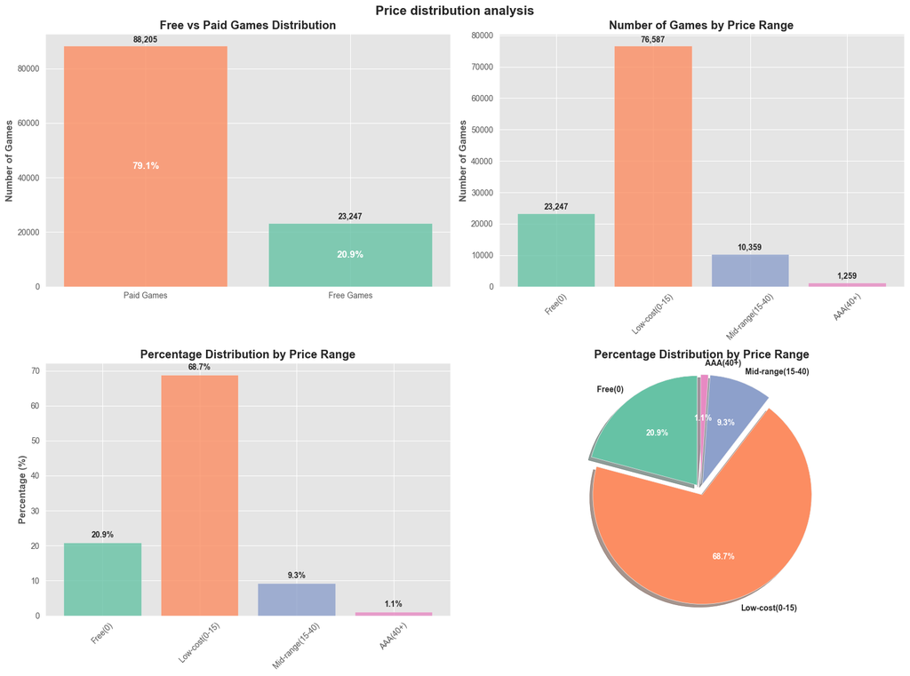

```
=== Detailed Price Range Statistics ===
Number of games by price range:
price_range
Free(0)             23247
Low-cost(0-15)      76587
Mid-range(15-40)    10359
AAA(40+)             1259
Name: count, dtype: int64

Percentage distribution by price range:
price_range
Free(0)             20.9
Low-cost(0-15)      68.7
Mid-range(15-40)     9.3
AAA(40+)             1.1
Name: proportion, dtype: float64
```

```python
plt.rcParams['font.sans-serif'] = ['SimHei', 'DejaVu Sans']
plt.rcParams['axes.unicode_minus'] = False

# 设置样式
sns.set_style("whitegrid")
plt.style.use('ggplot')

# 创建价格分类列
df['price_category'] = df['price'].apply(lambda x: 'Free Games' if x == 0 else 'Paid Games')

# 计算统计信息
free_count = (df['price'] == 0).sum()
paid_count = (df['price'] > 0).sum()
total_count = len(df)

free_percentage = (free_count / total_count) * 100
paid_percentage = (paid_count / total_count) * 100

print("=== Analysis of Game Price Distribution ===")
print(f"Total number of games: {total_count:,}")
print(f"Free games: {free_count:,} ({free_percentage:.1f}%)")
print(f"Paid Games: {paid_count:,} ({paid_percentage:.1f}%)")
print(f"Average price: ${df['price'].mean():.2f}")
print(f"Median price: ${df['price'].median():.2f}")
print(f"Minimum price: ${df['price'].min():.2f}")
print(f"Maximum price: ${df['price'].max():.2f}")
print(f"Standard deviation: ${df['price'].std():.2f}")

# 定义价格区间
bins = [-1, 0, 15, 40, float('inf')]
labels = ['Free(0)', 'Low-cost(0-15)', 'Mid-range(15-40)', 'AAA(40+)']

# 创建价格区间列
df['price_range'] = pd.cut(df['price'], bins=bins, labels=labels)

# 计算分布
price_distribution = df['price_range'].value_counts().sort_index()
price_percentage = df['price_range'].value_counts(normalize=True).sort_index() * 100

# 创建2x2的子图布局
fig, ((ax1, ax2), (ax3, ax4)) = plt.subplots(2, 2, figsize=(16, 12))
fig.suptitle('Price distribution analysis', fontsize=16, fontweight='bold', y=0.98)

# 1. 免费vs付费游戏数量对比 (左上)
colors1 = ['#fc8d62','#66c2a5']
categories = ['Paid Games', 'Free Games']
counts = [paid_count, free_count]
percentages = [paid_percentage, free_percentage]

bars1 = ax1.bar(categories, counts, color=colors1, alpha=0.8)
ax1.set_title('Free vs Paid Games Distribution', fontweight='bold')
ax1.set_ylabel('Number of Games', fontweight='bold')

# 在柱子上添加数值和百分比标签
for i, (bar, count, percentage) in enumerate(zip(bars1, counts, percentages)):
    height = bar.get_height()
    ax1.text(bar.get_x() + bar.get_width()/2., height/2,
             f'{percentage:.1f}%', ha='center', va='center',
             fontweight='bold', fontsize=12, color='white')
    ax1.text(bar.get_x() + bar.get_width()/2., height + max(counts)*0.01,
             f'{count:,}', ha='center', va='bottom', fontweight='bold')

# 2. 价格区间数量分布 (右上)
colors2 = ['#66c2a5', '#fc8d62', '#8da0cb', '#e78ac3']
bars2 = ax2.bar(price_distribution.index, price_distribution.values, color=colors2, alpha=0.8)
ax2.set_title('Number of Games by Price Range', fontweight='bold')
ax2.set_ylabel('Number of Games', fontweight='bold')
ax2.tick_params(axis='x', rotation=45)

# 在柱子上添加数值标签
for i, (bar, count) in enumerate(zip(bars2, price_distribution.values)):
    height = bar.get_height()
    ax2.text(bar.get_x() + bar.get_width()/2., height + max(price_distribution.values)*0.01,
             f'{count:,}', ha='center', va='bottom', fontweight='bold')

# 3. 价格区间百分比分布 (左下)
bars3 = ax3.bar(price_percentage.index, price_percentage.values, color=colors2, alpha=0.8)
ax3.set_title('Percentage Distribution by Price Range', fontweight='bold')
ax3.set_ylabel('Percentage (%)', fontweight='bold')
ax3.tick_params(axis='x', rotation=45)

# 在柱子上添加百分比标签
for i, (bar, percentage) in enumerate(zip(bars3, price_percentage.values)):
    height = bar.get_height()
    ax3.text(bar.get_x() + bar.get_width()/2., height + 1,
             f'{percentage:.1f}%', ha='center', va='bottom', fontweight='bold')

# 4. 价格区间饼图 (右下)
explode = (0.05, 0.05, 0.05, 0.05)
wedges, texts, autotexts = ax4.pie(price_percentage.values,
                                   labels=price_percentage.index,
                                   autopct='%1.1f%%',
                                   colors=colors2,
                                   explode=explode,
                                   startangle=90,
                                   shadow=True)

# 美化饼图文本
plt.setp(autotexts, size=10, weight="bold", color='white')
plt.setp(texts, size=10, weight="bold")
ax4.set_title('Percentage Distribution by Price Range', fontweight='bold')
ax4.axis('equal')

plt.tight_layout()
plt.show()

# 打印详细的统计信息
print("\n=== Detailed Price Range Statistics ===")
print("Number of games by price range:")
print(price_distribution)
print("\nPercentage distribution by price range:")
print(price_percentage.round(1))
```

## 2. 📊 Basic Statistical Analysis

- Numerical field descriptive statistics
  - 💰 Price distribution analysis
  - 💰 Games sales distribution
  - 🔞 Age rating distribution
  - 🏆 Achievement count statistics
- Platform support analysis
  - Windows/Mac/Linux support ratios
- Metacritic score analysis

```
Sales range distribution statistics:
0 - 20000           :  70206 games |  63.0%
0 - 0               :  22091 games |  19.8%
20000 - 50000       :   8277 games |   7.4%
50000 - 100000      :   4068 games |   3.7%
100000 - 200000     :   2664 games |   2.4%
200000 - 500000     :   2206 games |   2.0%
500000 - 1000000    :    921 games |   0.8%
1000000 - 2000000   :    525 games |   0.5%
2000000 - 5000000   :    336 games |   0.3%
5000000 - 10000000  :     93 games |   0.1%
10000000 - 20000000 :     38 games |   0.0%
20000000 - 50000000 :     21 games |   0.0%
50000000 - 100000000:      5 games |   0.0%
100000000 - 200000000:      1 games |   0.0%
```

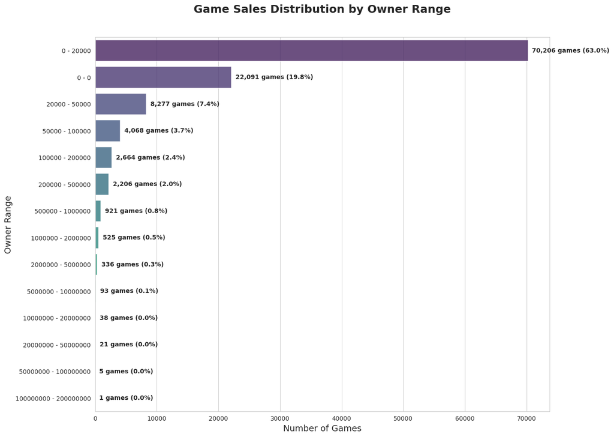

```
============================================================
Game Sales Distribution Summary:
============================================================
Total number of games: 111,452
Number of unique sales ranges: 14
Most common sales range: 0 - 20000
Number of games in this range: 70,206
Percentage of games in most common range: 63.0%
============================================================

Top 5 most common sales ranges:
----------------------------------------
1. 0 - 20000           :  70206 games ( 63.0%)
2. 0 - 0               :  22091 games ( 19.8%)
3. 20000 - 50000       :   8277 games (  7.4%)
4. 50000 - 100000      :   4068 games (  3.7%)
5. 100000 - 200000     :   2664 games (  2.4%)
```

```python
# 设置Seaborn风格和字体
sns.set_style("whitegrid")
plt.rcParams['font.sans-serif'] = ['DejaVu Sans', 'Arial']  # 使用英文字体
plt.rcParams['axes.unicode_minus'] = False



# 计算销量区间的分布
owner_distribution = df['estimated_owners'].value_counts()
owner_percentage = df['estimated_owners'].value_counts(normalize=True) * 100

# 按数量排序以便更好地展示
owner_distribution_sorted = owner_distribution.sort_values(ascending=False)
owner_percentage_sorted = owner_percentage[owner_distribution_sorted.index]

print("Sales range distribution statistics:")
for owner_range, count in owner_distribution_sorted.items():
    percentage = owner_percentage[owner_range]
    print(f"{owner_range:20}: {count:>6} games | {percentage:>5.1f}%")

# 创建可视化图表 - 只需要一个水平条形图
plt.figure(figsize=(14, 10))
colors = sns.color_palette("viridis", len(owner_distribution_sorted))

# 创建水平条形图
barplot = sns.barplot(x=owner_distribution_sorted.values,
                     y=owner_distribution_sorted.index,
                     palette=colors, alpha=0.8,hue=owner_distribution_sorted.index,legend=False)

plt.title('Game Sales Distribution by Owner Range\n',
          fontsize=18, fontweight='bold', pad=20)
plt.xlabel('Number of Games', fontsize=14)
plt.ylabel('Owner Range', fontsize=14)

# 在柱子上添加数值标签和百分比
for i, (count, owner_range) in enumerate(zip(owner_distribution_sorted.values, owner_distribution_sorted.index)):
    percentage = owner_percentage[owner_range]
    plt.text(count + max(owner_distribution_sorted.values)*0.01, i,
             f'{count:,} games ({percentage:.1f}%)',
             ha='left', va='center', fontweight='bold', fontsize=10)

plt.tight_layout()
plt.show()



# 输出统计摘要
print("=" * 60)
print("Game Sales Distribution Summary:")
print("=" * 60)
print(f"Total number of games: {len(df):,}")
print(f"Number of unique sales ranges: {len(owner_distribution):,}")
print(f"Most common sales range: {owner_distribution.index[0]}")
print(f"Number of games in this range: {owner_distribution.iloc[0]:,}")
print(f"Percentage of games in most common range: {owner_percentage.iloc[0]:.1f}%")
print("=" * 60)

# 额外输出：前5个最常见的销量区间
print("\nTop 5 most common sales ranges:")
print("-" * 40)
for i, (owner_range, count) in enumerate(owner_distribution_sorted.head(5).items(), 1):
    percentage = owner_percentage[owner_range]
    print(f"{i}. {owner_range:20}: {count:>6} games ({percentage:>5.1f}%)")
```

## 2. 📊 Basic Statistical Analysis

- Numerical field descriptive statistics
  - 💰 Price distribution analysis
  - 💰 Games sales distribution
  - 🔞 Age rating distribution
  - 🏆 Achievement count statistics
- Platform support analysis
  - Windows/Mac/Linux support ratios
- Metacritic score analysis

```
=== Age Rating Basic Statistics ===
Total games: 111,452
Games with age rating: 1,747
Games for all ages (rating=0): 109,705

Age rating value counts:
required_age
0     109705
1          1
3          9
5          1
6          6
7          7
9          1
10        38
11         1
12        36
13       223
14         6
15         9
16        71
17       976
18       354
19         1
20         2
21         5
Name: count, dtype: int64

Age rating descriptive stats:
count    111452.000000
mean          0.254208
std           2.035653
min           0.000000
25%           0.000000
50%           0.000000
75%           0.000000
max          21.000000
Name: required_age, dtype: float64
```

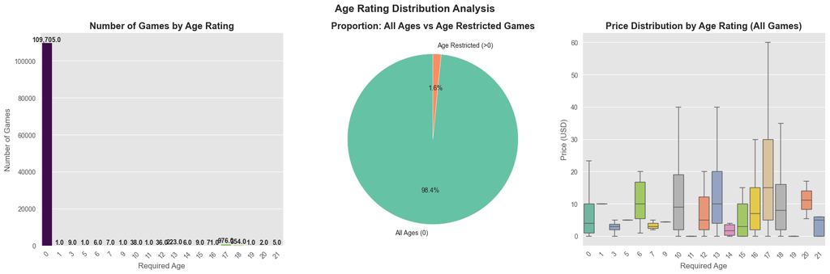

```python
# 设置中文字体（如果需要）
plt.rcParams['font.sans-serif'] = ['SimHei', 'DejaVu Sans']
plt.rcParams['axes.unicode_minus'] = False

# 设置样式
sns.set_style("whitegrid")
plt.style.use('ggplot')

# 查看年龄评级的基本统计
print("=== Age Rating Basic Statistics ===")
print(f"Total games: {len(df):,}")
print(f"Games with age rating: {(df['required_age'] > 0).sum():,}")
print(f"Games for all ages (rating=0): {(df['required_age'] == 0).sum():,}")

print("\nAge rating value counts:")
age_counts = df['required_age'].value_counts().sort_index()
print(age_counts)

print("\nAge rating descriptive stats:")
print(df['required_age'].describe())

# 创建子图 - 一行三列
fig, (ax1, ax2, ax3) = plt.subplots(1, 3, figsize=(18, 6))
fig.suptitle('Age Rating Distribution Analysis', fontsize=16, fontweight='bold')

# 1. 柱状图 - 显示每个年龄评级的游戏数量
age_order = sorted(df['required_age'].unique())
sns.countplot(data=df, x='required_age', ax=ax1, palette='viridis', order=age_order, hue=df['required_age'], legend=False)
ax1.set_title('Number of Games by Age Rating', fontweight='bold')
ax1.set_xlabel('Required Age')
ax1.set_ylabel('Number of Games')
ax1.tick_params(axis='x', rotation=45)

# 添加数值标签
for p in ax1.patches:
    ax1.annotate(f'{p.get_height():,}',
                (p.get_x() + p.get_width()/2., p.get_height()),
                ha='center', va='bottom', fontweight='bold')

# 2. 饼图 - 显示年龄评级占比
age_0_count = (df['required_age'] == 0).sum()
age_above_0_count = (df['required_age'] > 0).sum()

labels = ['All Ages (0)', 'Age Restricted (>0)']
sizes = [age_0_count, age_above_0_count]
colors = ['#66c2a5', '#fc8d62']

ax2.pie(sizes, labels=labels, autopct='%1.1f%%', colors=colors, startangle=90)
ax2.set_title('Proportion: All Ages vs Age Restricted Games', fontweight='bold')

# 3. 按年龄评级分组的价格分析 - 修改这里！
# 使用所有数据，包括required_age=0
sns.boxplot(data=df, x='required_age', y='price', ax=ax3,
           showfliers=False, palette='Set2', hue=df['required_age'], legend=False)
ax3.set_title('Price Distribution by Age Rating (All Games)', fontweight='bold')
ax3.set_xlabel('Required Age')
ax3.set_ylabel('Price (USD)')
ax3.tick_params(axis='x', rotation=45)

plt.tight_layout()
plt.show()
```

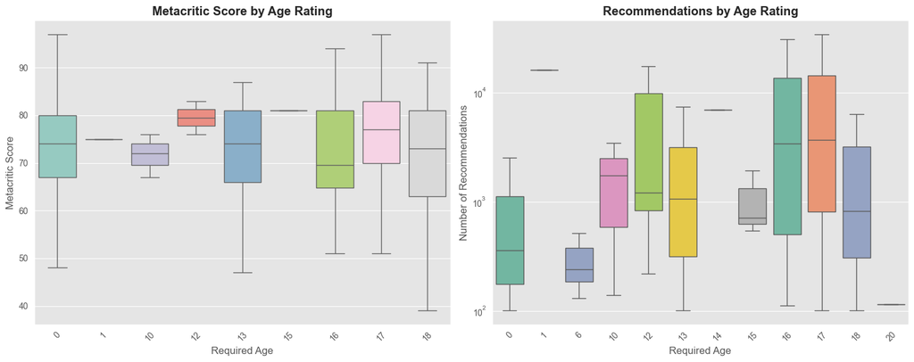

```python
# 年龄评级与游戏评分的关系
fig, (ax1, ax2) = plt.subplots(1, 2, figsize=(15, 6))

# 1. 年龄评级 vs Metacritic评分
age_metacritic = df[df['metacritic_score'] > 0]  # 只分析有评分的游戏
sns.boxplot(data=age_metacritic, x='required_age', y='metacritic_score',
           ax=ax1, showfliers=False, palette='Set3',hue=age_metacritic['required_age'], legend=False)
ax1.set_title('Metacritic Score by Age Rating', fontweight='bold')
ax1.set_xlabel('Required Age')
ax1.set_ylabel('Metacritic Score')
ax1.tick_params(axis='x', rotation=45)

# 2. 年龄评级 vs 用户推荐数
age_recommendations = df[df['recommendations'] > 0]  # 只分析有推荐数的游戏
sns.boxplot(data=age_recommendations, x='required_age', y='recommendations',
           ax=ax2, showfliers=False, palette='Set2',hue=age_recommendations['required_age'], legend=False)
ax2.set_title('Recommendations by Age Rating', fontweight='bold')
ax2.set_xlabel('Required Age')
ax2.set_ylabel('Number of Recommendations')
ax2.tick_params(axis='x', rotation=45)
ax2.set_yscale('log')  # 使用对数尺度因为推荐数差异很大

plt.tight_layout()
plt.show()
```

## 2. 📊 Basic Statistical Analysis

- Numerical field descriptive statistics
  - 💰 Price distribution analysis
  - 💰 Games sales distribution
  - 🔞 Age rating distribution
  - 🏆 Achievement count statistics
- Platform support analysis
  - Windows/Mac/Linux support ratios
- Metacritic score analysis

```
=== Achievement Count Basic Statistics ===
Total games: 111,452
Games without achievements: 57,702
Games with achievements: 53,750

Achievement count descriptive stats:
count    111452.000000
mean         17.511144
std         150.139008
min           0.000000
25%           0.000000
50%           0.000000
75%          17.000000
max        9821.000000
Name: achievements, dtype: float64
```

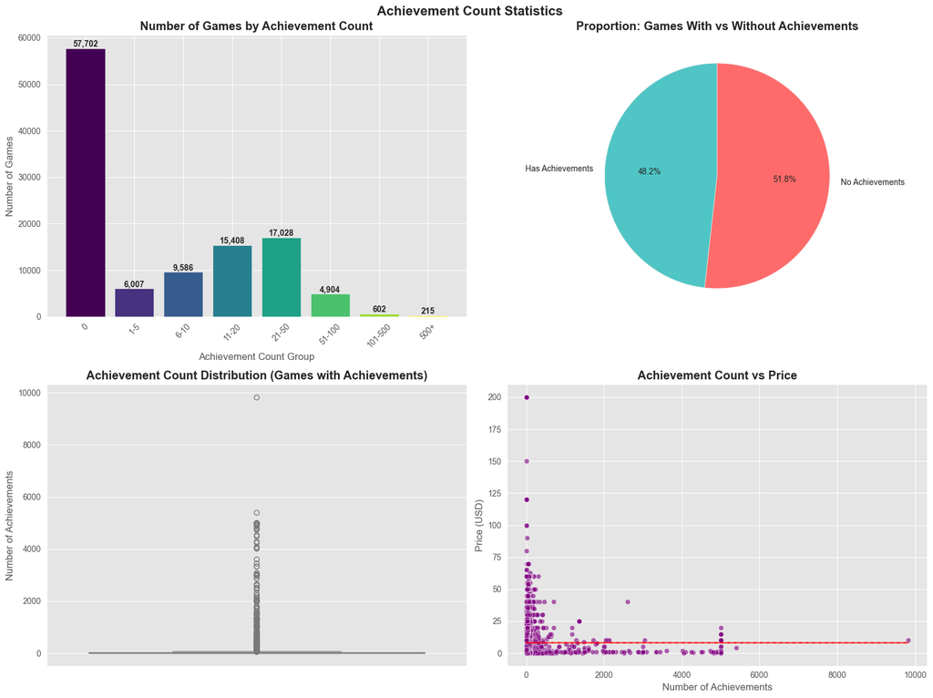

```
=== Correlation Analysis ===
Correlation matrix (games with achievements only):
achievements                1.000000
average_playtime_forever    0.019320
recommendations             0.012035
positive                    0.012016
metacritic_score            0.008623
price                      -0.000063
Name: achievements, dtype: float64

=== Average Values by Achievement Group ===
                   price  metacritic_score  recommendations  positive  \
achievement_group
0                    NaN               NaN              NaN       NaN
1-5                 4.27              0.31            92.95    127.02
6-10                6.48              0.90            92.99    130.60
11-20               6.83              2.97           317.26    412.76
21-50              10.76              6.67          1194.27   1361.03
51-100             10.61              8.69          3350.18   3877.93
101-500            11.20             16.41         17449.45  25279.42
500+                4.70              2.85          4779.47   9345.01

                   average_playtime_forever
achievement_group
0                                       NaN
1-5                                   18.21
6-10                                  37.04
11-20                                 62.07
21-50                                145.13
51-100                               285.76
101-500                             1106.99
500+                                 350.93
```

```python
# 设置中文字体（如果需要）
plt.rcParams['font.sans-serif'] = ['SimHei', 'DejaVu Sans']
plt.rcParams['axes.unicode_minus'] = False

# 设置样式
sns.set_style("whitegrid")
plt.style.use('ggplot')


# 查看成就数量的基本统计
print("=== Achievement Count Basic Statistics ===")
print(f"Total games: {len(df):,}")
print(f"Games without achievements: {(df['achievements'] == 0).sum():,}")
print(f"Games with achievements: {(df['achievements'] > 0).sum():,}")

print("\nAchievement count descriptive stats:")
print(df['achievements'].describe())

# 创建分组变量用于可视化
df['achievement_group'] = pd.cut(
    df['achievements'],
    bins=[-1, 0, 5, 10, 20, 50, 100, 500, 10000],
    labels=['0', '1-5', '6-10', '11-20', '21-50', '51-100', '101-500', '500+']
)

# 创建子图
fig, ((ax1, ax2), (ax3, ax4)) = plt.subplots(2, 2, figsize=(16, 12))
fig.suptitle('Achievement Count Statistics', fontsize=16, fontweight='bold')

# 1. 柱状图 - 显示每个成就数量分组的游戏数量
group_order = ['0', '1-5', '6-10', '11-20', '21-50', '51-100', '101-500', '500+']
group_counts = df['achievement_group'].value_counts().reindex(group_order)

bars = ax1.bar(group_order, group_counts, color=plt.cm.viridis(np.linspace(0, 1, len(group_order))))
ax1.set_title('Number of Games by Achievement Count', fontweight='bold')
ax1.set_xlabel('Achievement Count Group')
ax1.set_ylabel('Number of Games')
ax1.tick_params(axis='x', rotation=45)

# 添加数值标签
for bar, count in zip(bars, group_counts):
    height = bar.get_height()
    ax1.text(bar.get_x() + bar.get_width()/2., height + 5,
             f'{count:,}', ha='center', va='bottom', fontweight='bold')

# 2. 饼图 - 显示有无成就的游戏占比
has_achievements = (df['achievements'] > 0).sum()
no_achievements = (df['achievements'] == 0).sum()

labels = ['Has Achievements', 'No Achievements']
sizes = [has_achievements, no_achievements]
colors = ['#50c5c5', '#ff6b6b']

ax2.pie(sizes, labels=labels, autopct='%1.1f%%', colors=colors, startangle=90)
ax2.set_title('Proportion: Games With vs Without Achievements', fontweight='bold')

# 3. 箱线图 - 显示成就数量的分布（只包含有成就的游戏）
achievement_data = df[df['achievements'] > 0]
sns.boxplot(data=achievement_data, y='achievements', ax=ax3, color='lightblue')
ax3.set_title('Achievement Count Distribution (Games with Achievements)', fontweight='bold')
ax3.set_ylabel('Number of Achievements')

# 4. 成就数量与价格的关系
achievement_price_data = df[df['achievements'] > 0]  # 只分析有成就的游戏
sns.scatterplot(data=achievement_price_data, x='achievements', y='price',
                alpha=0.6, ax=ax4, color='purple')
ax4.set_title('Achievement Count vs Price', fontweight='bold')
ax4.set_xlabel('Number of Achievements')
ax4.set_ylabel('Price (USD)')

# 添加趋势线
z = np.polyfit(achievement_price_data['achievements'], achievement_price_data['price'], 1)
p = np.poly1d(z)
ax4.plot(achievement_price_data['achievements'], p(achievement_price_data['achievements']),
         "r--", alpha=0.8)

plt.tight_layout()
plt.show()

# 额外分析：成就数量与其他指标的关系
print("\n=== Correlation Analysis ===")
correlation_data = df[df['achievements'] > 0]  # 只分析有成就的游戏
correlations = correlation_data[['achievements', 'price', 'metacritic_score',
                                'recommendations', 'positive', 'average_playtime_forever']].corr()

print("Correlation matrix (games with achievements only):")
print(correlations['achievements'].sort_values(ascending=False))

# 分析不同成就数量区间的游戏特性
print("\n=== Average Values by Achievement Group ===")
achievement_groups = df[df['achievements'] > 0].groupby('achievement_group', observed=False)
group_stats = achievement_groups.agg({
    'price': 'mean',
    'metacritic_score': 'mean',
    'recommendations': 'mean',
    'positive': 'mean',
    'average_playtime_forever': 'mean'
}).round(2)

print(group_stats)
```

## 2. 📊 Basic Statistical Analysis

- Numerical field descriptive statistics
  - 💰 Price distribution analysis
  - 💰 Games sales distribution
  - 🔞 Age rating distribution
  - 🏆 Achievement count statistics
- Platform support analysis
  - Windows/Mac/Linux support ratios
- Metacritic score analysis

```
=== PLATFORM SUPPORT ANALYSIS ===
Total games in dataset: 111452

Platform Support Counts:
Windows supported: 111,419 (100.0%)
Mac supported: 19,376 (17.4%)
Linux supported: 13,686 (12.3%)

Platform Combinations:
Win: 88,569 (79.5%)
WinMacLin: 10,178 (9.1%)
WinMac: 9,172 (8.2%)
WinLin: 3,500 (3.1%)
Mac: 25 (0.0%)
Lin: 7 (0.0%)
MacLin: 1 (0.0%)
```

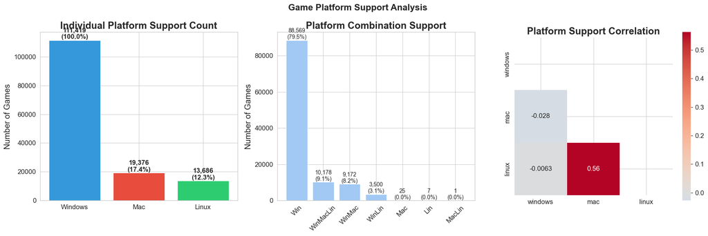

```python
# Set up visualization style
sns.set_style("whitegrid")
sns.set_palette("pastel")
rcParams['figure.figsize'] = (15, 10)  # 调整整体图形大小
plt.rcParams['font.size'] = 12

# Basic platform statistics
print("=== PLATFORM SUPPORT ANALYSIS ===")
print(f"Total games in dataset: {len(df)}")
print(f"\nPlatform Support Counts:")
print(f"Windows supported: {df['windows'].sum():,} ({df['windows'].mean()*100:.1f}%)")
print(f"Mac supported: {df['mac'].sum():,} ({df['mac'].mean()*100:.1f}%)")
print(f"Linux supported: {df['linux'].sum():,} ({df['linux'].mean()*100:.1f}%)")

# Platform combination analysis
df['platform_combo'] = df.apply(lambda x:
                               f"{'Win' if x['windows'] else ''}"
                               f"{'Mac' if x['mac'] else ''}"
                               f"{'Lin' if x['linux'] else ''}", axis=1)
df['platform_combo'] = df['platform_combo'].replace('', 'None')

platform_combo_counts = df['platform_combo'].value_counts()
print(f"\nPlatform Combinations:")
for combo, count in platform_combo_counts.items():
    print(f"{combo}: {count:,} ({count/len(df)*100:.1f}%)")

# Create subplots - 现在只有3个图表 (1x3布局)
fig, axes = plt.subplots(1, 3, figsize=(18, 6))
fig.suptitle('Game Platform Support Analysis', fontsize=16, fontweight='bold')

# 3.1 Individual Platform Support Bar Chart
platform_data = {
    'Platform': ['Windows', 'Mac', 'Linux'],
    'Count': [df['windows'].sum(), df['mac'].sum(), df['linux'].sum()],
    'Percentage': [df['windows'].mean()*100, df['mac'].mean()*100, df['linux'].mean()*100]
}

bars = axes[0].bar(platform_data['Platform'], platform_data['Count'],
                  color=['#3498db', '#e74c3c', '#2ecc71'])
axes[0].set_title('Individual Platform Support Count', fontweight='bold')
axes[0].set_ylabel('Number of Games')
for i, bar in enumerate(bars):
    height = bar.get_height()
    axes[0].text(bar.get_x() + bar.get_width()/2., height + 50,
                f'{platform_data["Count"][i]:,}\n({platform_data["Percentage"][i]:.1f}%)',
                ha='center', va='bottom', fontweight='bold')

# 3.2 Platform Combination Bar Chart
combo_df = pd.DataFrame({
    'Combination': platform_combo_counts.index,
    'Count': platform_combo_counts.values
})
combo_df = combo_df.sort_values('Count', ascending=False)

bars = axes[1].bar(combo_df['Combination'], combo_df['Count'])
axes[1].set_title('Platform Combination Support', fontweight='bold')
axes[1].set_ylabel('Number of Games')
axes[1].tick_params(axis='x', rotation=45)
for i, bar in enumerate(bars):
    height = bar.get_height()
    percentage = (height / len(df)) * 100
    axes[1].text(bar.get_x() + bar.get_width()/2., height + 20,
                f'{height:,}\n({percentage:.1f}%)',
                ha='center', va='bottom', fontsize=10)

# 3.3 Platform Support Heatmap (Correlation between platforms)
platform_corr = df[['windows', 'mac', 'linux']].corr()
mask = np.triu(np.ones_like(platform_corr, dtype=bool))
sns.heatmap(platform_corr, annot=True, cmap='coolwarm', center=0,
           square=True, mask=mask, ax=axes[2])
axes[2].set_title('Platform Support Correlation', fontweight='bold')

plt.tight_layout()
plt.show()
```

## 2. 📊 Basic Statistical Analysis

- Numerical field descriptive statistics
  - 💰 Price distribution analysis
  - 💰 Games sales distribution
  - 🔞 Age rating distribution
  - 🏆 Achievement count statistics
- Platform support analysis
  - Windows/Mac/Linux support ratios
- Metacritic score analysis

```
Total number of games: 111452
Number of games with Metacritic scores: 4005
Percentage of games with scores: 3.59%

Metacritic Score Statistics:
count    4005.000000
mean       73.003246
std        10.619391
min         8.000000
25%        67.000000
50%        75.000000
75%        80.000000
max        97.000000
Name: metacritic_score, dtype: float64
```

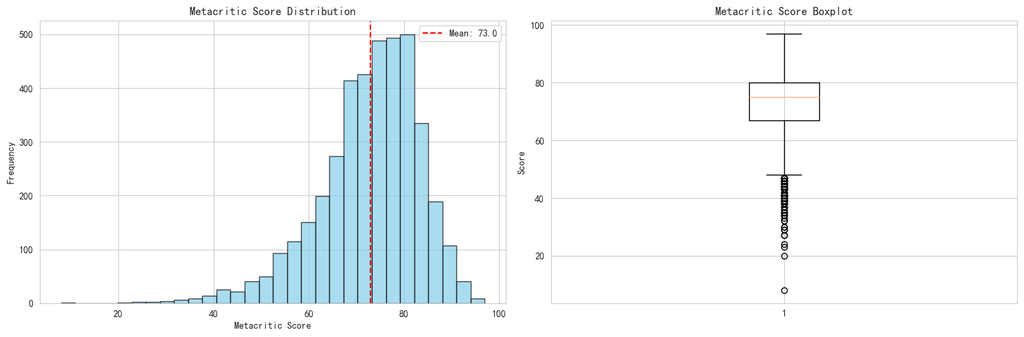

```
Score Category Distribution:
score_category
Excellent (90-100)     113
Fair (60-69)           850
Good (70-79)          1543
Great (80-89)         1067
Poor (0-59)            432
Name: count, dtype: int64
```

[figure not shown]

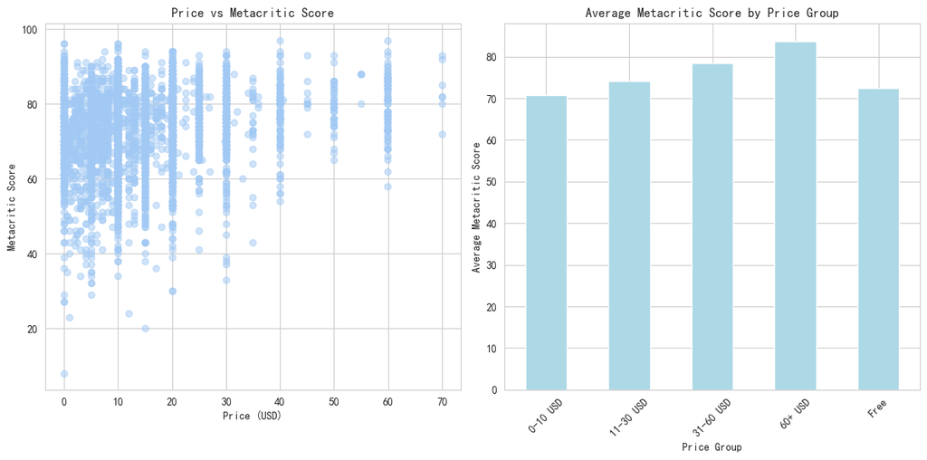

```
Average Scores by Price Range:
              mean  count    std
price_group
0-10 USD     70.79   1552  11.05
11-30 USD    74.14   1871   9.79
31-60 USD    78.41    265   8.27
60+ USD      83.71      7   7.23
Free         72.36    310  12.17
Average Metacritic Scores by Game Genre:
                       mean_score  game_count  std_score
genres_list
RPG                         73.82         857      10.06
Sports                      73.48         133       9.86
Free to Play                73.45         102      10.46
Strategy                    72.92         979      10.24
Adventure                   72.89        1756      10.10
Casual                      72.77         493       9.01
Action                      72.71        2016      11.34
Massively Multiplayer       72.62          79      10.07
Indie                       72.35        2169      10.10
Racing                      71.82         138      12.15
```

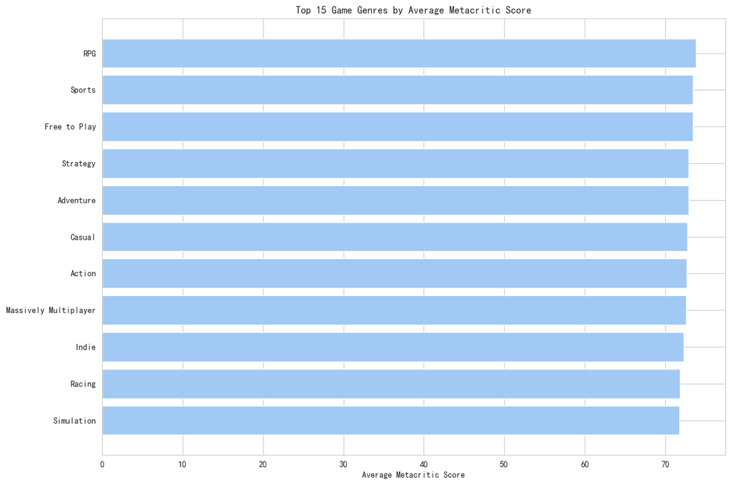

```
Score Statistics by Platform Support:
        mean  count platform
True   73.00   4005  windows
False  72.30   2448      mac
True   74.10   1557      mac
False  72.58   2933    linux
True   74.16   1072    linux
```

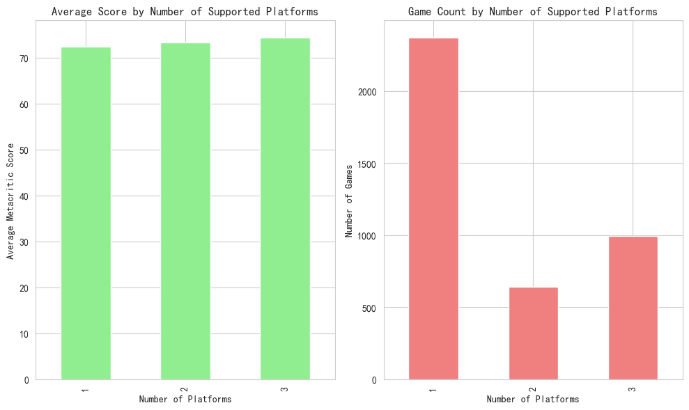

```
Correlation Matrix Between Variables:
                          metacritic_score  positive_ratio  price  \
metacritic_score                     1.000           0.585  0.213
positive_ratio                       0.585           1.000  0.133
price                                0.213           0.133  1.000
achievements                         0.067           0.051  0.145
dlc_count                            0.072           0.032  0.211
average_playtime_forever             0.136           0.088  0.126

                          achievements  dlc_count  average_playtime_forever
metacritic_score                 0.067      0.072                     0.136
positive_ratio                   0.051      0.032                     0.088
price                            0.145      0.211                     0.126
achievements                     1.000      0.194                     0.153
dlc_count                        0.194      1.000                     0.135
average_playtime_forever         0.153      0.135                     1.000
```

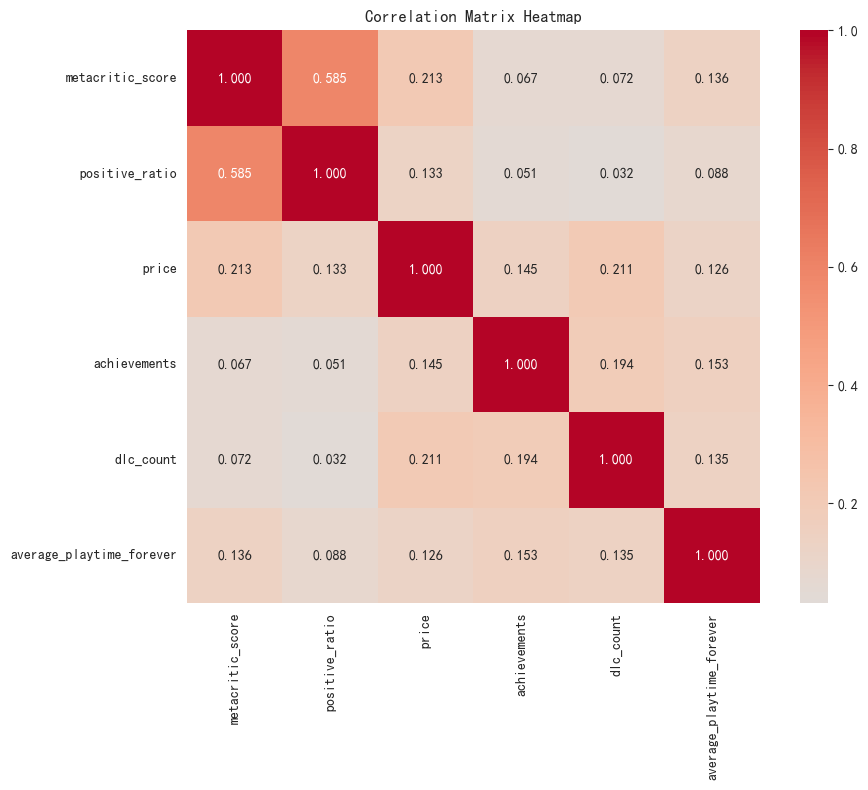

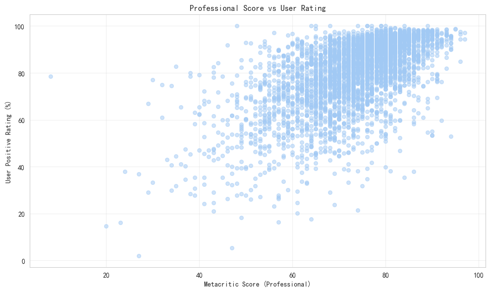

```
Successfully parsed dates: 4005/4005
Date parsing success rate: 100.00%
Yearly Score Trends:
              avg_score  median_score  total_games
release_year
2016              71.19          73.0          374
2017              72.67          74.0          345
2018              72.10          73.0          356
2019              73.19          76.0          269
2020              74.19          76.0          291
2021              76.45          77.0          224
2022              78.06          80.0           78
2023              79.55          80.0           64
2024              81.38          82.0           69
2025              76.79          80.5           24
```

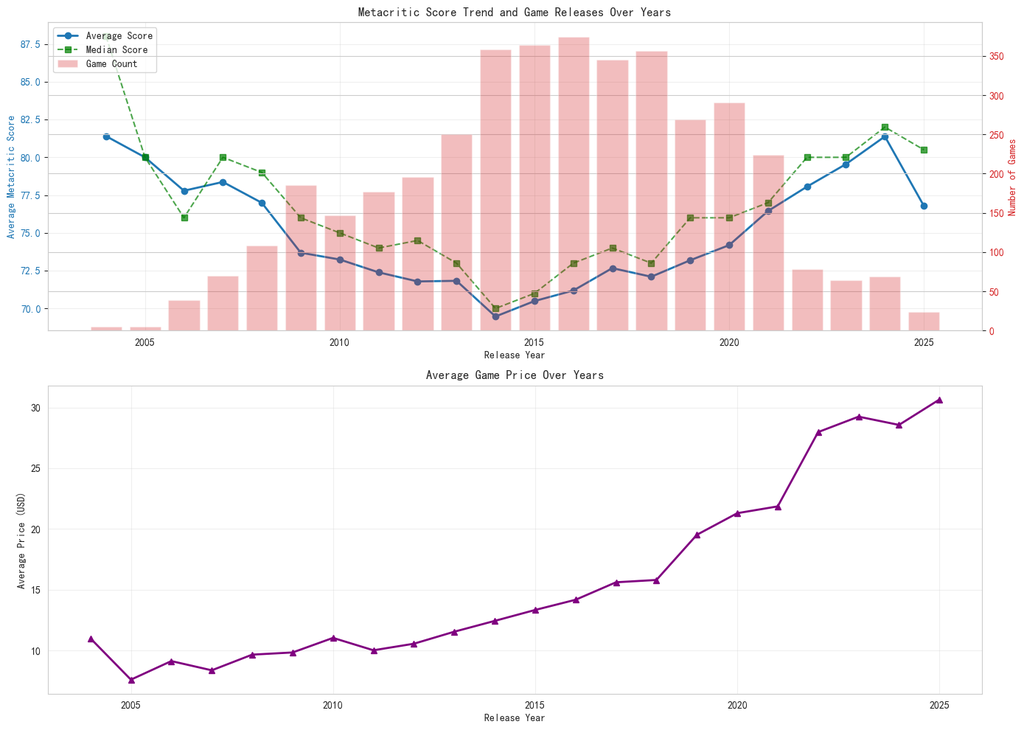

```
============================================================
METACRITIC SCORE ANALYSIS SUMMARY
============================================================
1. Basic Statistics:
   - Average Score: 73.0
   - Median Score: 75.0
   - Score Standard Deviation: 10.6

2. Score Distribution:
   - Excellent (90-100): 113 games (2.8%)
   - Great (80-89): 1067 games (26.6%)
   - Good (70-79): 1543 games (38.5%)

3. Key Insights:
   Highest Rated Games:
   - Disco Elysium - The Final Cut: 97 points (['RPG'])
   - Persona 5 Royal: 97 points (['RPG'])
   - BioShock™: 96 points (['Action', 'RPG'])
   - Half-Life 2: 96 points (['Action'])
   - Half-Life: 96 points (['Action'])

4. Free vs Paid Games:
   - Free Games Average Score: 72.4
   - Paid Games Average Score: 73.1
```

```python
# Filter out data with metacritic_score of 0 (indicating no rating)
df_metacritic = df[df['metacritic_score'] > 0].copy()

print(f"Total number of games: {len(df)}")
print(f"Number of games with Metacritic scores: {len(df_metacritic)}")
print(f"Percentage of games with scores: {len(df_metacritic)/len(df)*100:.2f}%")

# Basic statistics of Metacritic scores
print("\nMetacritic Score Statistics:")
print(df_metacritic['metacritic_score'].describe())

# Score distribution visualization
fig, axes = plt.subplots(1, 2, figsize=(15, 5))

# Histogram
axes[0].hist(df_metacritic['metacritic_score'], bins=30, alpha=0.7, color='skyblue', edgecolor='black')
axes[0].set_xlabel('Metacritic Score')
axes[0].set_ylabel('Frequency')
axes[0].set_title('Metacritic Score Distribution')
axes[0].axvline(df_metacritic['metacritic_score'].mean(), color='red', linestyle='--', label=f'Mean: {df_metacritic["metacritic_score"].mean():.1f}')
axes[0].legend()

# Box plot
axes[1].boxplot(df_metacritic['metacritic_score'])
axes[1].set_title('Metacritic Score Boxplot')
axes[1].set_ylabel('Score')

plt.tight_layout()
plt.show()

# Create score categories
def score_category(score):
    if score >= 90:
        return 'Excellent (90-100)'
    elif score >= 80:
        return 'Great (80-89)'
    elif score >= 70:
        return 'Good (70-79)'
    elif score >= 60:
        return 'Fair (60-69)'
    else:
        return 'Poor (0-59)'

df_metacritic['score_category'] = df_metacritic['metacritic_score'].apply(score_category)

# Score category distribution
score_dist = df_metacritic['score_category'].value_counts().sort_index()
print("Score Category Distribution:")
print(score_dist)

# Visualize score categories
plt.figure(figsize=(10, 6))
score_dist.plot(kind='bar', color=['red', 'orange', 'yellow', 'lightgreen', 'green'])
plt.title('Metacritic Score Categories Distribution')
plt.xlabel('Score Category')
plt.ylabel('Number of Games')
plt.xticks(rotation=45)
plt.tight_layout()
plt.show()

# Price vs Score relationship
plt.figure(figsize=(12, 6))

# Scatter plot
plt.subplot(1, 2, 1)
plt.scatter(df_metacritic['price'], df_metacritic['metacritic_score'], alpha=0.5)
plt.xlabel('Price (USD)')
plt.ylabel('Metacritic Score')
plt.title('Price vs Metacritic Score')

# Price group analysis
def price_group(price):
    if price == 0:
        return 'Free'
    elif price <= 10:
        return '0-10 USD'
    elif price <= 30:
        return '11-30 USD'
    elif price <= 60:
        return '31-60 USD'
    else:
        return '60+ USD'

df_metacritic['price_group'] = df_metacritic['price'].apply(price_group)

plt.subplot(1, 2, 2)
price_score = df_metacritic.groupby('price_group')['metacritic_score'].mean().sort_index()
price_score.plot(kind='bar', color='lightblue')
plt.title('Average Metacritic Score by Price Group')
plt.xlabel('Price Group')
plt.ylabel('Average Metacritic Score')
plt.xticks(rotation=45)

plt.tight_layout()
plt.show()

# Detailed statistics by price group
print("\nAverage Scores by Price Range:")
print(df_metacritic.groupby('price_group')['metacritic_score'].agg(['mean', 'count', 'std']).round(2))

# Process genres field (assuming string-formatted lists)
def parse_list_string(s):
    try:
        if isinstance(s, str):
            return ast.literal_eval(s)
        return s
    except:
        return []

df_metacritic['genres_list'] = df_metacritic['genres'].apply(parse_list_string)

# Expand genres for analysis
genres_expanded = df_metacritic.explode('genres_list')

# Average scores by genre (only genres with sufficient samples)
genre_stats = genres_expanded.groupby('genres_list').agg({
    'metacritic_score': ['mean', 'count', 'std']
}).round(2)

genre_stats.columns = ['mean_score', 'game_count', 'std_score']
genre_stats = genre_stats[genre_stats['game_count'] >= 10].sort_values('mean_score', ascending=False)

print("Average Metacritic Scores by Game Genre:")
print(genre_stats.head(10))

# Visualize top 15 genres by average score
plt.figure(figsize=(12, 8))
top_genres = genre_stats.head(15)
plt.barh(range(len(top_genres)), top_genres['mean_score'])
plt.yticks(range(len(top_genres)), top_genres.index)
plt.xlabel('Average Metacritic Score')
plt.title('Top 15 Game Genres by Average Metacritic Score')
plt.gca().invert_yaxis()
plt.tight_layout()
plt.show()

# Platform support vs score relationship
platform_cols = ['windows', 'mac', 'linux']
platform_stats = []

for platform in platform_cols:
    stats = df_metacritic.groupby(platform)['metacritic_score'].agg(['mean', 'count']).round(2)
    stats['platform'] = platform
    platform_stats.append(stats)

platform_summary = pd.concat(platform_stats)
print("Score Statistics by Platform Support:")
print(platform_summary)

# Multi-platform support vs score relationship
df_metacritic['platform_count'] = df_metacritic[platform_cols].sum(axis=1)

plt.figure(figsize=(10, 6))
platform_score = df_metacritic.groupby('platform_count')['metacritic_score'].mean()
platform_count = df_metacritic.groupby('platform_count').size()

plt.subplot(1, 2, 1)
platform_score.plot(kind='bar', color='lightgreen')
plt.title('Average Score by Number of Supported Platforms')
plt.xlabel('Number of Platforms')
plt.ylabel('Average Metacritic Score')

plt.subplot(1, 2, 2)
platform_count.plot(kind='bar', color='lightcoral')
plt.title('Game Count by Number of Supported Platforms')
plt.xlabel('Number of Platforms')
plt.ylabel('Number of Games')

plt.tight_layout()
plt.show()

# 1. Correlation between user ratings and professional scores
df_metacritic['total_reviews'] = df_metacritic['positive'] + df_metacritic['negative']
df_metacritic['positive_ratio'] = df_metacritic['positive'] / df_metacritic['total_reviews']

# Calculate correlation coefficients
correlation_matrix = df_metacritic[['metacritic_score', 'positive_ratio', 'price',
                                   'achievements', 'dlc_count', 'average_playtime_forever']].corr()

print("Correlation Matrix Between Variables:")
print(correlation_matrix.round(3))

# Visualize correlation matrix
plt.figure(figsize=(10, 8))
sns.heatmap(correlation_matrix, annot=True, cmap='coolwarm', center=0,
            square=True, fmt='.3f')
plt.title('Correlation Matrix Heatmap')
plt.tight_layout()
plt.show()

# 2. Professional score vs user rating scatter plot
plt.figure(figsize=(10, 6))
plt.scatter(df_metacritic['metacritic_score'], df_metacritic['positive_ratio']*100,
            alpha=0.5, s=30)
plt.xlabel('Metacritic Score (Professional)')
plt.ylabel('User Positive Rating (%)')
plt.title('Professional Score vs User Rating')
plt.grid(True, alpha=0.3)

# Add trend line
z = np.polyfit(df_metacritic['metacritic_score'], df_metacritic['positive_ratio']*100, 1)
p = np.poly1d(z)
plt.plot(df_metacritic['metacritic_score'], p(df_metacritic['metacritic_score']), "r--", alpha=0.8)

plt.tight_layout()
plt.show()

# More robust date parsing function
def parse_release_date(date_str):
    """
    Parse release dates in multiple formats
    """
    if pd.isna(date_str):
        return pd.NaT

    date_str = str(date_str).strip()

    # Try multiple date formats
    formats = [
        '%b %d, %Y',  # "Apr 13, 2015"
        '%B %d, %Y',  # "April 13, 2015"
        '%b %Y',      # "Nov 2014"
        '%B %Y',      # "November 2014"
        '%Y-%m-%d',   # "2015-04-13"
        '%m/%d/%Y',   # "04/13/2015"
        '%d/%m/%Y',   # "13/04/2015"
        '%Y',         # "2015"
    ]

    for fmt in formats:
        try:
            return pd.to_datetime(date_str, format=fmt)
        except:
            continue

    # If all formats fail, return NaT
    return pd.NaT

# Apply date parsing
df_metacritic['release_date_parsed'] = df_metacritic['release_date'].apply(parse_release_date)

# Check parsing results
date_parsed_count = df_metacritic['release_date_parsed'].notna().sum()
print(f"Successfully parsed dates: {date_parsed_count}/{len(df_metacritic)}")
print(f"Date parsing success rate: {date_parsed_count/len(df_metacritic)*100:.2f}%")

# View examples of failed date parsing (if any)
failed_dates = df_metacritic[df_metacritic['release_date_parsed'].isna()]['release_date'].unique()
if len(failed_dates) > 0:
    print(f"\nExamples of failed date formats:")
    for date in failed_dates[:5]:
        print(f"  - {date}")

# Extract year and month
df_metacritic['release_year'] = df_metacritic['release_date_parsed'].dt.year
df_metacritic['release_month'] = df_metacritic['release_date_parsed'].dt.month
df_metacritic['release_quarter'] = df_metacritic['release_date_parsed'].dt.quarter

# 1. Yearly score trend analysis
yearly_stats = df_metacritic[df_metacritic['release_year'].notna()].groupby('release_year').agg({
    'metacritic_score': ['mean', 'median', 'count'],
    'price': 'mean',
    'name': 'count'
}).round(2)

yearly_stats.columns = ['avg_score', 'median_score', 'scored_games', 'avg_price', 'total_games']
yearly_stats = yearly_stats[yearly_stats['total_games'] >= 5]  # Only include years with sufficient data

print("Yearly Score Trends:")
print(yearly_stats[['avg_score', 'median_score', 'total_games']].tail(10))

# Visualize yearly trends
fig, (ax1, ax2) = plt.subplots(2, 1, figsize=(14, 10))

# Subplot 1: Average scores and game counts
color = 'tab:blue'
ax1.set_xlabel('Release Year')
ax1.set_ylabel('Average Metacritic Score', color=color)
line1 = ax1.plot(yearly_stats.index, yearly_stats['avg_score'],
                color=color, marker='o', linewidth=2, label='Average Score')
ax1.tick_params(axis='y', labelcolor=color)
ax1.grid(True, alpha=0.3)

# Add median line
ax1.plot(yearly_stats.index, yearly_stats['median_score'],
        color='green', marker='s', linestyle='--', alpha=0.7, label='Median Score')

ax2_bar = ax1.twinx()
color = 'tab:red'
ax2_bar.set_ylabel('Number of Games', color=color)
bars = ax2_bar.bar(yearly_stats.index, yearly_stats['total_games'],
                  alpha=0.3, color=color, label='Game Count')
ax2_bar.tick_params(axis='y', labelcolor=color)

# Combine legends
lines1, labels1 = ax1.get_legend_handles_labels()
lines2, labels2 = ax2_bar.get_legend_handles_labels()
ax1.legend(lines1 + lines2, labels1 + labels2, loc='upper left')

ax1.set_title('Metacritic Score Trend and Game Releases Over Years')

# Subplot 2: Yearly price trends
ax2.plot(yearly_stats.index, yearly_stats['avg_price'],
        color='purple', marker='^', linewidth=2)
ax2.set_xlabel('Release Year')
ax2.set_ylabel('Average Price (USD)')
ax2.set_title('Average Game Price Over Years')
ax2.grid(True, alpha=0.3)

plt.tight_layout()
plt.show()

# Generate analysis summary
print("=" * 60)
print("METACRITIC SCORE ANALYSIS SUMMARY")
print("=" * 60)

print(f"1. Basic Statistics:")
print(f"   - Average Score: {df_metacritic['metacritic_score'].mean():.1f}")
print(f"   - Median Score: {df_metacritic['metacritic_score'].median():.1f}")
print(f"   - Score Standard Deviation: {df_metacritic['metacritic_score'].std():.1f}")

print(f"\n2. Score Distribution:")
for category in ['Excellent (90-100)', 'Great (80-89)', 'Good (70-79)']:
    count = len(df_metacritic[df_metacritic['score_category'] == category])
    percentage = count / len(df_metacritic) * 100
    print(f"   - {category}: {count} games ({percentage:.1f}%)")

print(f"\n3. Key Insights:")
# Find highest-rated games
top_games = df_metacritic.nlargest(5, 'metacritic_score')[['name', 'metacritic_score', 'genres']]
print("   Highest Rated Games:")
for idx, row in top_games.iterrows():
    print(f"   - {row['name']}: {row['metacritic_score']} points ({row['genres']})")

# Price vs score insights
free_avg = df_metacritic[df_metacritic['price'] == 0]['metacritic_score'].mean()
paid_avg = df_metacritic[df_metacritic['price'] > 0]['metacritic_score'].mean()
print(f"\n4. Free vs Paid Games:")
print(f"   - Free Games Average Score: {free_avg:.1f}")
print(f"   - Paid Games Average Score: {paid_avg:.1f}")
```

## 3. 📅 Time Series Analysis

- Annual game release trends
- Quarterly/monthly release patterns
- Special year/event impact analysis and advanced time series analysis

```
=== RELEASE DATE DATA PREPROCESSING ===
Release date unique values sample: ['Oct 21, 2008' 'Oct 12, 2017' 'Nov 17, 2021' 'Jul 23, 2020' 'Feb 3, 2020'
 'Feb 26, 2021' 'Jan 9, 2022' 'May 5, 2022' 'Apr 2, 2020' 'Nov 11, 2014']
Release date dtype: object
Missing values: 0

After conversion:
Date range: 1997-06-30 00:00:00 to 2025-05-30 00:00:00
Missing values after conversion: 131

=== ANNUAL RELEASE TRENDS ===
Games released by year:
1997.0: 2 games
1998.0: 1 games
1999.0: 3 games
2000.0: 2 games
2001.0: 4 games
2002.0: 1 games
2003.0: 3 games
2004.0: 7 games
2005.0: 7 games
2006.0: 69 games
2007.0: 109 games
2008.0: 176 games
2009.0: 339 games
2010.0: 300 games
2011.0: 286 games
2012.0: 356 games
2013.0: 490 games
2014.0: 1,627 games
2015.0: 2,683 games
2016.0: 4,407 games
2017.0: 6,324 games
2018.0: 8,166 games
2019.0: 7,810 games
2020.0: 9,631 games
2021.0: 12,376 games
2022.0: 13,979 games
2023.0: 15,543 games
2024.0: 20,583 games
```

[output cut: 8 more lines]

```

=== MONTHLY RELEASE PATTERNS ===
Average releases by month:
January: 8,720 games (7.8%)
February: 9,360 games (8.4%)
March: 10,332 games (9.3%)
April: 9,085 games (8.2%)
May: 8,925 games (8.0%)
June: 8,050 games (7.2%)
July: 8,898 games (8.0%)
August: 9,286 games (8.3%)
September: 9,150 games (8.2%)
October: 10,281 games (9.2%)
November: 9,884 games (8.9%)
December: 9,350 games (8.4%)
```

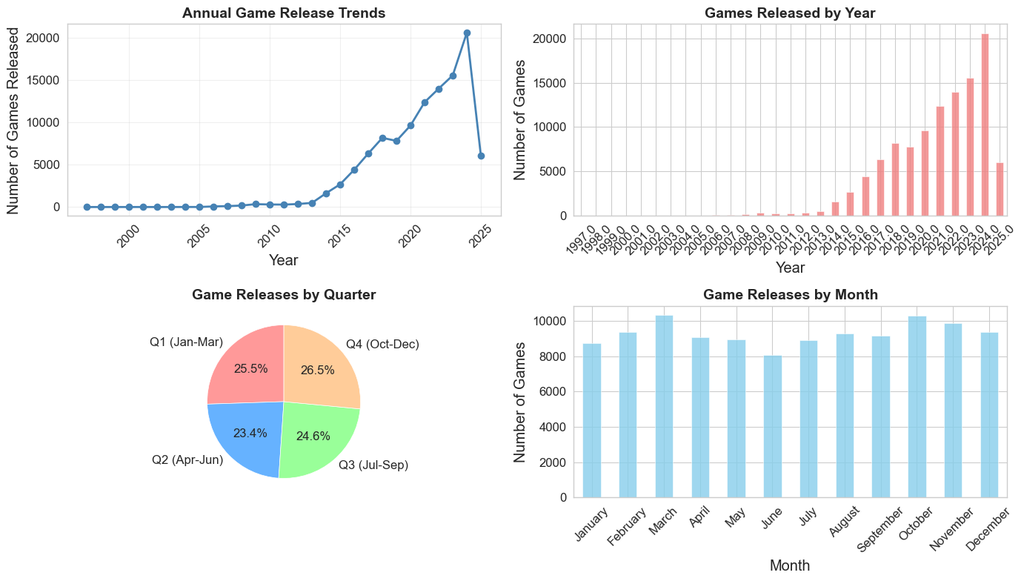

```python
# 1. 首先检查和处理 release_date 字段
print("=== RELEASE DATE DATA PREPROCESSING ===")
print(f"Release date unique values sample: {df['release_date'].unique()[:10]}")
print(f"Release date dtype: {df['release_date'].dtype}")
print(f"Missing values: {df['release_date'].isnull().sum()}")

# 将字符串日期转换为datetime格式
df['release_date'] = pd.to_datetime(df['release_date'], errors='coerce')

# 检查转换后的情况
print(f"\nAfter conversion:")
print(f"Date range: {df['release_date'].min()} to {df['release_date'].max()}")
print(f"Missing values after conversion: {df['release_date'].isnull().sum()}")

# 提取年份、季度、月份信息
df['release_year'] = df['release_date'].dt.year
df['release_quarter'] = df['release_date'].dt.quarter
df['release_month'] = df['release_date'].dt.month
df['release_month_name'] = df['release_date'].dt.month_name()

# 移除日期转换失败的行（如果有）
df = df.dropna(subset=['release_date'])

# 2. 年度游戏发布趋势分析
print("\n=== ANNUAL RELEASE TRENDS ===")

# 计算每年的游戏发布数量
annual_releases = df['release_year'].value_counts().sort_index()
print("Games released by year:")
for year, count in annual_releases.items():
    print(f"{year}: {count:,} games")

# 可视化年度趋势
plt.figure(figsize=(14, 8))

# 年度发布趋势线图
plt.subplot(2, 2, 1)
annual_releases.plot(kind='line', marker='o', color='steelblue', linewidth=2)
plt.title('Annual Game Release Trends', fontweight='bold', fontsize=14)
plt.xlabel('Year')
plt.ylabel('Number of Games Released')
plt.grid(True, alpha=0.3)
plt.xticks(rotation=45)

# 年度发布柱状图
plt.subplot(2, 2, 2)
annual_releases.plot(kind='bar', color='lightcoral', alpha=0.8)
plt.title('Games Released by Year', fontweight='bold', fontsize=14)
plt.xlabel('Year')
plt.ylabel('Number of Games')
plt.xticks(rotation=45)

# 3. 季度发布模式分析
print("\n=== QUARTERLY RELEASE PATTERNS ===")

# 计算每个季度的平均发布数量
quarterly_avg = df.groupby('release_quarter').size()
quarterly_avg_percent = (quarterly_avg / quarterly_avg.sum()) * 100

print("Average releases by quarter:")
for quarter, (count, percent) in enumerate(zip(quarterly_avg, quarterly_avg_percent), 1):
    print(f"Q{quarter}: {count:,} games ({percent:.1f}%)")

# 季度分布饼图
plt.subplot(2, 2, 3)
quarters = ['Q1 (Jan-Mar)', 'Q2 (Apr-Jun)', 'Q3 (Jul-Sep)', 'Q4 (Oct-Dec)']
colors = ['#FF9999', '#66B2FF', '#99FF99', '#FFCC99']
plt.pie(quarterly_avg, labels=quarters, autopct='%1.1f%%', colors=colors, startangle=90)
plt.title('Game Releases by Quarter', fontweight='bold', fontsize=14)

# 4. 月度发布模式分析
print("\n=== MONTHLY RELEASE PATTERNS ===")

monthly_releases = df['release_month_name'].value_counts()
month_order = ['January', 'February', 'March', 'April', 'May', 'June',
               'July', 'August', 'September', 'October', 'November', 'December']
monthly_releases = monthly_releases.reindex(month_order)

print("Average releases by month:")
for month, count in monthly_releases.items():
    percent = (count / monthly_releases.sum()) * 100
    print(f"{month}: {count:,} games ({percent:.1f}%)")

# 月度发布柱状图
plt.subplot(2, 2, 4)
monthly_releases.plot(kind='bar', color='skyblue', alpha=0.8)
plt.title('Game Releases by Month', fontweight='bold', fontsize=14)
plt.xlabel('Month')
plt.ylabel('Number of Games')
plt.xticks(rotation=45)

plt.tight_layout()
plt.show()
```

## 3. 📅 Time Series Analysis

- Annual game release trends
- Quarterly/monthly release patterns
- Special year/event impact analysis and advanced time series analysis

```
=== SPECIAL YEAR/EVENT IMPACT ANALYSIS ===
Year-over-year growth rates:
1998.0: -50.0%
1999.0: +200.0%
2000.0: -33.3%
2001.0: +100.0%
2002.0: -75.0%
2003.0: +200.0%
2004.0: +133.3%
2005.0: +0.0%
2006.0: +885.7%
2007.0: +58.0%
2008.0: +61.5%
2009.0: +92.6%
2010.0: -11.5%
2011.0: -4.7%
2012.0: +24.5%
2013.0: +37.6%
2014.0: +232.0%
2015.0: +64.9%
2016.0: +64.3%
2017.0: +43.5%
2018.0: +29.1%
2019.0: -4.4%
2020.0: +23.3%
2021.0: +28.5%
2022.0: +13.0%
2023.0: +11.2%
2024.0: +32.4%
2025.0: -70.7%

Anomalous years (outside 1.5 std dev):
2022.0: 13,979 games (+1.8 std dev)
2023.0: 15,543 games (+2.0 std dev)
2024.0: 20,583 games (+2.9 std dev)
```

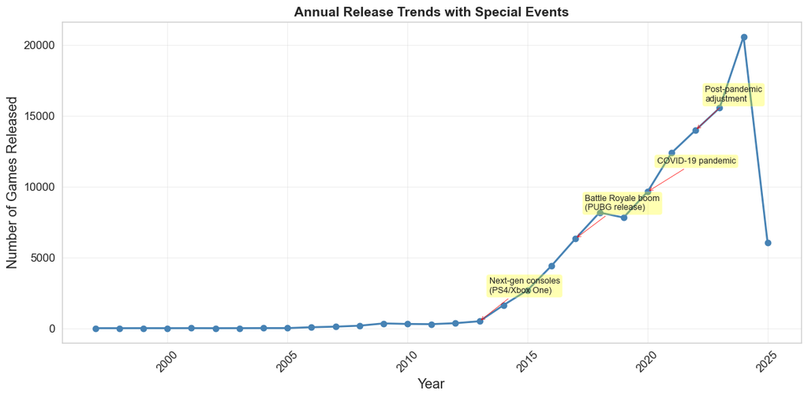

```
=== ADVANCED TIME SERIES ANALYSIS ===
```

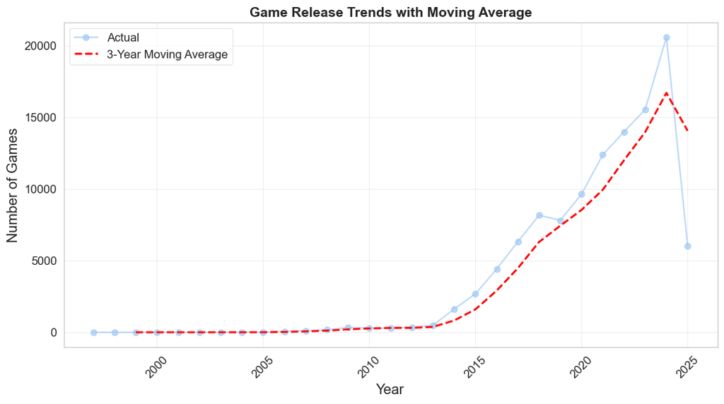

```python
# 5. 特殊年份/事件影响分析
print("\n=== SPECIAL YEAR/EVENT IMPACT ANALYSIS ===")

# 计算年度增长率
annual_growth = annual_releases.pct_change() * 100
print("Year-over-year growth rates:")
for year, growth in annual_growth.items():
    if not pd.isna(growth):
        print(f"{year}: {growth:+.1f}%")

# 识别异常年份
mean_releases = annual_releases.mean()
std_releases = annual_releases.std()
anomaly_threshold = 1.5  # 1.5个标准差

anomalous_years = annual_releases[(annual_releases > mean_releases + std_releases * anomaly_threshold) |
                                 (annual_releases < mean_releases - std_releases * anomaly_threshold)]

print(f"\nAnomalous years (outside {anomaly_threshold} std dev):")
for year, count in anomalous_years.items():
    deviation = (count - mean_releases) / std_releases
    print(f"{year}: {count:,} games ({deviation:+.1f} std dev)")

# 特殊事件影响可视化
plt.figure(figsize=(12, 6))

# 标注特殊事件
plt.plot(annual_releases.index, annual_releases.values, marker='o', linewidth=2, color='steelblue')

# 假设的特殊事件（您可以根据实际情况修改）
special_events = {
    2013: 'Next-gen consoles\n(PS4/Xbox One)',
    2017: 'Battle Royale boom\n(PUBG release)',
    2020: 'COVID-19 pandemic',
    2022: 'Post-pandemic\nadjustment'
}

for year, event in special_events.items():
    if year in annual_releases.index:
        plt.annotate(event,
                    xy=(year, annual_releases[year]),
                    xytext=(10, 30),
                    textcoords='offset points',
                    arrowprops=dict(arrowstyle='->', color='red'),
                    bbox=dict(boxstyle='round,pad=0.3', fc='yellow', alpha=0.3),
                    fontsize=9)

plt.title('Annual Release Trends with Special Events', fontweight='bold', fontsize=14)
plt.xlabel('Year')
plt.ylabel('Number of Games Released')
plt.grid(True, alpha=0.3)
plt.xticks(rotation=45)
plt.tight_layout()
plt.show()

# 6. 深入时间序列分析
print("\n=== ADVANCED TIME SERIES ANALYSIS ===")

# 移动平均分析
rolling_avg = annual_releases.rolling(window=3).mean()  # 3年移动平均

plt.figure(figsize=(12, 6))
plt.plot(annual_releases.index, annual_releases.values, 'o-', label='Actual', alpha=0.7)
plt.plot(rolling_avg.index, rolling_avg.values, 'r--', label='3-Year Moving Average', linewidth=2)
plt.title('Game Release Trends with Moving Average', fontweight='bold', fontsize=14)
plt.xlabel('Year')
plt.ylabel('Number of Games')
plt.legend()
plt.grid(True, alpha=0.3)
plt.xticks(rotation=45)
plt.show()
```